# Scale independence

2023-03-31

## Introduction

An example data set was creqated by selecting the first 200 genes from the full data set and then added 5 candidate loci selected to ensure that this example data set included loci that had significant relationships with the phenotype. This data was loaded into R and analyzed following the tutorial provided at the WGCNA author’s website

https://horvath.genetics.ucla.edu/html/CoexpressionNetwork/Rpackages/WGCNA/Tutorials/index.html

and specifically the content in the below document.

https://horvath.genetics.ucla.edu/html/CoexpressionNetwork/Rpackages/WGCNA/Tutorials/FemaleLiver-02-networkConstr-auto.pdf

```r
t1 <- Sys.time()
expData <- read.table(file = "W103first200.tsv", header = TRUE, sep  ="\t")
expData[1:3, 1:8]
#
nrow(expData)
#ncol(expData) - 4

datExpr <- expData[, -c(1:4)]
expData <- expData[, 1:4]
#expData[1:3, ]

#names(datExpr) <- paste("Sample", 1:ncol(datExpr), sep  ="")
names(datExpr) <- paste("Sample", sub("^X", "", colnames(datExpr)), sep = "")
rownames(datExpr) <- expData$ID
datExpr <- t(datExpr)
```

## WGCNA

```r
library(WGCNA)
```

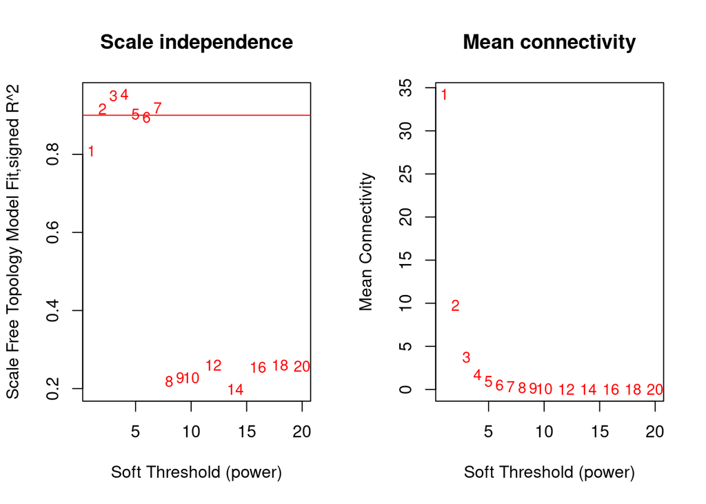

**Figure 1.** Scale free topology and mean connectivity as a function of soft threshold. Values for soft threshold were chosen following the code in the tutorial.

```r
# Choose a set of soft-thresholding powers
powers = c(c(1:10), seq(from = 12, to=20, by=2))
# Call the network topology analysis function
enableWGCNAThreads(nThreads = 2)
sft = pickSoftThreshold(datExpr, powerVector = powers, verbose = 5)

# Plot the results:
#sizeGrWindow(9, 5)
par(mfrow = c(1,2))
cex1 = 0.9
# Scale-free topology fit index as a function of the soft-thresholding power
plot(sft$fitIndices[,1], -sign(sft$fitIndices[,3])*sft$fitIndices[,2],
xlab="Soft Threshold (power)",ylab="Scale Free Topology Model Fit,signed R^2",type="n",
main = paste("Scale independence"));
text(sft$fitIndices[,1], -sign(sft$fitIndices[,3])*sft$fitIndices[,2],
labels=powers,cex=cex1,col="red");
# this line corresponds to using an R^2 cut-off of h
abline(h=0.90,col="red")
# Mean connectivity as a function of the soft-thresholding power
plot(sft$fitIndices[,1], sft$fitIndices[,5],
xlab="Soft Threshold (power)",ylab="Mean Connectivity", type="n",
main = paste("Mean connectivity"))
text(sft$fitIndices[,1], sft$fitIndices[,5], labels=powers, cex=cex1,col="red")
```

```r
par(mfrow = c(1,1))
```

The plots in Figure 1 illustrate the reuse of code provided in the WGCNA author’s tutorial but implemented on our example data set of 205 genes. Values for scale free topology are insensitive to values of soft threshold from 1 to 7. Values for scale free topology are are similarly insensitive to values of soft threshold from 8 to 20, however the scale free topology was a lower value than for soft threshold values from 1 to 7. Mean connectivity decreases dramatically for soft threshold values between 1 and 6, after soft threshold reaches a value of about 8 the mean connectivity has approached zero and appears insensitive to increasing values of soft threshold. This is similar to the tutorial where a soft threshold of 6 was eventually chosen.

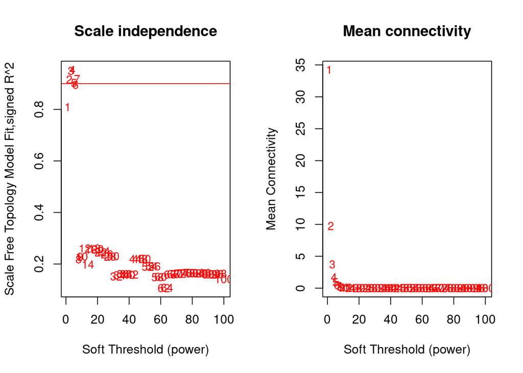

**Figure 2.** Scale free topology and mean connectivity as a function of soft threshold. Values for soft threshold were selected based on those in the tutorial but extended to include values up to 100.

```r
# Choose a set of soft-thresholding powers
# powers = c(c(1:10), seq(from = 12, to=20, by=2))
powers = c(c(1:10), seq(from = 12, to=100, by=2))
# Call the network topology analysis function
enableWGCNAThreads(nThreads = 2)
sft = pickSoftThreshold(datExpr, powerVector = powers, verbose = 0)


# Plot the results:
#sizeGrWindow(9, 5)
par(mfrow = c(1,2))
cex1 = 0.9
# Scale-free topology fit index as a function of the soft-thresholding power
plot(sft$fitIndices[,1], -sign(sft$fitIndices[,3])*sft$fitIndices[,2],
xlab="Soft Threshold (power)",ylab="Scale Free Topology Model Fit,signed R^2",type="n",
main = paste("Scale independence"));
text(sft$fitIndices[,1], -sign(sft$fitIndices[,3])*sft$fitIndices[,2],
labels=powers,cex=cex1,col="red");
# this line corresponds to using an R^2 cut-off of h
abline(h=0.90,col="red")
# Mean connectivity as a function of the soft-thresholding power
plot(sft$fitIndices[,1], sft$fitIndices[,5],
xlab="Soft Threshold (power)",ylab="Mean Connectivity", type="n",
main = paste("Mean connectivity"))
text(sft$fitIndices[,1], sft$fitIndices[,5], labels=powers, cex=cex1,col="red")
```

```r
par(mfrow = c(1,1))
```

The panels in Figure 2 extend the plots from Figure 1 to include soft threshold values of up to 100. The scale free topology and mean connectivity appear insensitive to changes in soft threshold above a value of about 10. This appears consistent with Figure 1 as well as the example from the tutorial.